# Bureau of Labor Statistics: Consumer Price Index - Part I

Date: 08/13/17  
Vishal Bakshi  
vbakshi@ccsf.edu  
Source: https://download.bls.gov/pub/time.series/cu/

## Objective

The Bureau of Labor Statistics maintains and provides LABSTAT, a "central repository of data for the Bureau of Labor Statistics...considered the agency's database of record". One of the data sets in this database is the Consumer Price (CPI) Index Time Series, tracking the CPI in different geographic regions and categories of goods and services across the US. My goal for this post is to understand the data and mapping files, import the time series data, and create some basic visualizations of different trends over time.

### What is [CPI](https://en.m.wikipedia.org/wiki/Consumer_price_index)?

Consumer Price Index (CPI) is a measure of the costs of goods and/or services in a given year relative to the cost of the same quantity of goods and/or services at a past reference time.

$$CPI = \frac{\textit{cost of a good in a given year}}{\textit{cost of the good in the base year}} * 100$$

```python
from __future__ import print_function, division
import numpy as np
import pandas as pd
import math
import random
import matplotlib.pyplot as plt
import thinkstats2
import datetime
import matplotlib as mpl
from dateutil.relativedelta import relativedelta
```

### Import Data and Mapping Files

I first bring in all the current data in `cu.data.0.Current` which contains `series_id`, `year`, `period`, `value` and `footnote_codes` for each item in the time series:

```python
current = pd.read_csv("cu_current.txt", sep="\t")
current['seasonality'] = current['series_id'].str[2]
current['periodicity'] = current['series_id'].str[3:4]
current['area_code'] = current['series_id'].str[4:8]
current['item_code'] = current['series_id'].str[8:]
```

```python
current['item_code'] = current.item_code.str.strip()
```

```python
current.head()
```

|  | series_id | year | period | value | footnote_codes | seasonality | periodicity | area_code | item_code |
| --- | --- | --- | --- | --- | --- | --- | --- | --- | --- |
| 0 | CUSR0000SA0 | 1997 | M01 | 159.4 |  | S | R | 0000 | SA0 |
| 1 | CUSR0000SA0 | 1997 | M02 | 159.7 |  | S | R | 0000 | SA0 |
| 2 | CUSR0000SA0 | 1997 | M03 | 159.8 |  | S | R | 0000 | SA0 |
| 3 | CUSR0000SA0 | 1997 | M04 | 159.9 |  | S | R | 0000 | SA0 |
| 4 | CUSR0000SA0 | 1997 | M05 | 159.9 |  | S | R | 0000 | SA0 |

A `series_id` such as `CUSR0000SA0` includes the survey abbreviation `CU` (CPI for all urban consumers), the seasonality code `S` if the value is adjusted for seasonality and `U` if it's unadjusted, the periodicity code `R` if Regular or `S` if Semi-annual, the area code `0000` (code for the particular geographic area this value comes from), and the item code `SA0` (SA0 for all items in the index, SA0E for energy items, SAA for apparel, etc).

The period columns identifies either month `M01 - M12`, annual average `M13` or semi-annual term `S01 - S03`. Finally, the value columns identifies the CPI for that particular record.

The BLS data set LABSTAT also includes mapping files from the different codes to their text descriptions. I first converted it to a `.txt` file and then bring this into a DataFrame as well:

```python
item = pd.read_csv("cu_item.txt", sep='\t', index_col=False)
#In order to see the full item_name
pd.set_option('display.max_colwidth',100)
item.head()
```

|  | item_code | item_name | display_level | selectable | sort_sequence |
| --- | --- | --- | --- | --- | --- |
| 0 | AA0 | All items - old base | 0 | T | 2 |
| 1 | AA0R | Purchasing power of the consumer dollar - old base | 0 | T | 399 |
| 2 | SA0 | All items | 0 | T | 1 |
| 3 | SA0E | Energy | 1 | T | 374 |
| 4 | SA0L1 | All items less food | 1 | T | 358 |

I want to first observe the trend of the CPI of "All items" from 1997 to 2017:

```python
sa0 = current.query("item_code == 'SA0'")
sa0.head()
```

|  | series_id | year | period | value | footnote_codes | seasonality | periodicity | area_code | item_code |
| --- | --- | --- | --- | --- | --- | --- | --- | --- | --- |
| 0 | CUSR0000SA0 | 1997 | M01 | 159.4 |  | S | R | 0000 | SA0 |
| 1 | CUSR0000SA0 | 1997 | M02 | 159.7 |  | S | R | 0000 | SA0 |
| 2 | CUSR0000SA0 | 1997 | M03 | 159.8 |  | S | R | 0000 | SA0 |
| 3 | CUSR0000SA0 | 1997 | M04 | 159.9 |  | S | R | 0000 | SA0 |
| 4 | CUSR0000SA0 | 1997 | M05 | 159.9 |  | S | R | 0000 | SA0 |

There are 45 different areas from which the CPI samples are taken, initially I will focus on the U.S. city averages. The file `cu.area` with a list of areas is given in the LABSTAT data set for the CU time series. I first converted it to a `.txt` file before import:

```python
area = pd.read_csv("cu_area.txt", sep="\t")
area.head()
```

|  | area_code | area_name | display_level | selectable | sort_sequence |
| --- | --- | --- | --- | --- | --- |
| 0000 | U.S. city average | 0 | T | 1 | NaN |
| 0100 | Northeast urban | 0 | T | 5 | NaN |
| 0200 | Midwest urban | 0 | T | 12 | NaN |
| 0300 | South urban | 0 | T | 24 | NaN |
| 0400 | West urban | 0 | T | 34 | NaN |

I take a subset of only the monthly, [seasonally adjusted](https://en.m.wikipedia.org/wiki/Seasonal_adjustment) CPI of the U.S. city average (area_code: 0000) for all items (item_code: SA0). Seasonal adjustment removes any seasonal patterns in prices that may occur over the year. This adjustment allows a comparison of CPI in different months without the effects of seasonal price changes:

```python
us_monthly_sa0 = sa0.query("area_code == '0000' & seasonality == 'S'& period in ['M01', 'M02', 'M03', 'M04', 'M05', 'M06', 'M07', 'M08', 'M09', 'M10', 'M11', 'M12']")
us_monthly_sa0.head()
```

|  | series_id | year | period | value | footnote_codes | seasonality | periodicity | area_code | item_code |
| --- | --- | --- | --- | --- | --- | --- | --- | --- | --- |
| 0 | CUSR0000SA0 | 1997 | M01 | 159.4 |  | S | R | 0000 | SA0 |
| 1 | CUSR0000SA0 | 1997 | M02 | 159.7 |  | S | R | 0000 | SA0 |
| 2 | CUSR0000SA0 | 1997 | M03 | 159.8 |  | S | R | 0000 | SA0 |
| 3 | CUSR0000SA0 | 1997 | M04 | 159.9 |  | S | R | 0000 | SA0 |
| 4 | CUSR0000SA0 | 1997 | M05 | 159.9 |  | S | R | 0000 | SA0 |

The data includes monthly records from January 1997 to June 2017, a total of 246 months, so the length of the DataFrame should equal 246:

```python
len(us_monthly_sa0)
```

```
246
```

I create a list of dates corresponding to the months for which the values are given, and convert them to `datetime` objects so I can use them for my plots' x-axes:

```python
dates = []
m = 12
for i in range(21):
    if i == 20: m = 6
    for j in range(m):
        date = str(1997 + i) + '-' + str(j + 1).zfill(2) + '-' + str(1).zfill(2)
        dates.append(date)
pdates = [pd.to_datetime(date) for date in dates]
```

I then plot time vs. values of the U.S City Average CPI:

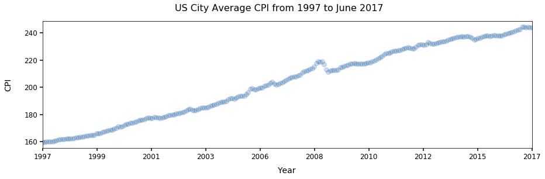

```python
xs = np.arange(0, len(us_monthly_sa0))
ys = us_monthly_sa0.value

fig = plt.figure(figsize=[15,4])
fig.suptitle('US City Average CPI from 1997 to June 2017', fontsize=16, family='helvetica')

plt.axes().set_xlabel('Year', fontsize=14, labelpad=10)
plt.axes().set_ylabel('CPI', fontsize=14, labelpad=20)
plt.xlim(pdates[0], pdates[-1])
plt.axes().xaxis.set_major_locator(mpl.ticker.LinearLocator(numticks=10))
plt.axes().tick_params(length=5, width=1.5, labelsize=12)

plt.scatter(pdates, ys, color='#08519c', alpha=0.2, s=60)
plt.show()
```

**Figure 1: Seasonally Adjusted CPI Over Time**

### Comparing Seasonally Adjusted and Unadjusted Trends

In the previous plot, I used the seasonally adjusted values, but I want to see how the difference between those and the adjusted CPI values is visualized.

```python
us_monthly_sa0u = sa0.query("area_code == '0000' & seasonality == 'U'& period in ['M01', 'M02', 'M03', 'M04', 'M05', 'M06', 'M07', 'M08', 'M09', 'M10', 'M11', 'M12']")
us_monthly_sa0u.head()
```

|  | series_id | year | period | value | footnote_codes | seasonality | periodicity | area_code | item_code |
| --- | --- | --- | --- | --- | --- | --- | --- | --- | --- |
| 69934 | CUUR0000SA0 | 1997 | M01 | 159.1 |  | U | R | 0000 | SA0 |
| 69935 | CUUR0000SA0 | 1997 | M02 | 159.6 |  | U | R | 0000 | SA0 |
| 69936 | CUUR0000SA0 | 1997 | M03 | 160.0 |  | U | R | 0000 | SA0 |
| 69937 | CUUR0000SA0 | 1997 | M04 | 160.2 |  | U | R | 0000 | SA0 |
| 69938 | CUUR0000SA0 | 1997 | M05 | 160.1 |  | U | R | 0000 | SA0 |

```python
len(us_monthly_sa0u)
```

```
246
```

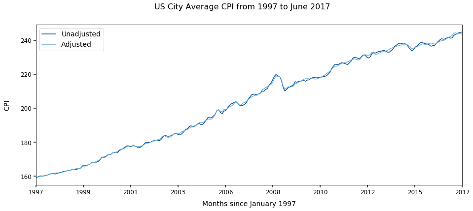

```python
xs = np.arange(0, len(us_monthly_sa0u))
ysu = us_monthly_sa0u.value

fig = plt.figure(figsize=[15.5,6])
fig.suptitle('US City Average CPI from 1997 to June 2017', fontsize=16, family='helvetica')

plt.axes().set_xlabel('Months since January 1997', fontsize=14, labelpad=10)
plt.axes().set_ylabel('CPI', fontsize=14, labelpad=20)
plt.xlim(pdates[0], pdates[-1])
plt.axes().xaxis.set_major_locator(mpl.ticker.LinearLocator(numticks=10))
plt.axes().tick_params(length=5, width=1.5, labelsize=12)

plt.plot(pdates, ysu, color='#08519c')
plt.plot(pdates, ys, color='#6baed6')
plt.legend(['Unadjusted', 'Adjusted'], prop={'size': 14})
plt.show()
```

**Figure 2: Comparison of Adjusted and Unadjusted CPI**

At this scale (20 years) the seasonal fluctuations are evident but unclear. I'll look at the difference between the two CPIs at a smaller time scale to observe any patterns:

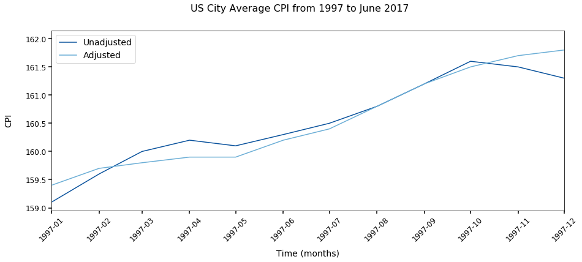

```python
import matplotlib.dates as mdates

xs = np.arange(0, 12)
ys = us_monthly_sa0.value[0:13]
ysu = us_monthly_sa0u.value[0:13]
dates = pdates[0:13]

fig = plt.figure(figsize=[15, 6])
fig.autofmt_xdate()
fig.suptitle('US City Average CPI from 1997 to June 2017', fontsize=16, family='helvetica')

plt.axes().set_xlabel('Time (months)', fontsize=14, labelpad=10)
plt.axes().set_ylabel('CPI', fontsize=14, labelpad=20)
plt.xlim(pdates[0], pdates[13])
plt.axes().xaxis.set_major_locator(mpl.ticker.AutoLocator())
plt.axes().tick_params(length=5, width=1.5, labelsize=12)

plt.plot(dates, ysu, color='#08519c')
plt.plot(dates, ys, color='#6baed6')
plt.xticks(rotation=45)
plt.legend(['Unadjusted', 'Adjusted'], prop={'size':14})

years = mdates.YearLocator()   # every year
months = mdates.MonthLocator()  # every month
yearsFmt = mdates.DateFormatter('%Y-%m')

plt.axes().xaxis.set_major_locator(months)
plt.axes().xaxis.set_major_formatter(yearsFmt)
plt.axes().xaxis.set_minor_locator(months)
plt.xlim(dates[0], dates[11])


plt.show()
```

**Figure 3: Comparison of Adjusted and Unadjusted CPI for 1997**

The `Unadjusted` CPI values vary more than the `Adjusted` values. The spikes in the trend are attenuated to a more gradual increase from January to December 1997. To see the periodic behavior of seasonal price changes, I plot the difference in `Adjusted` and `Unadjusted` values over the 20 year time interval:

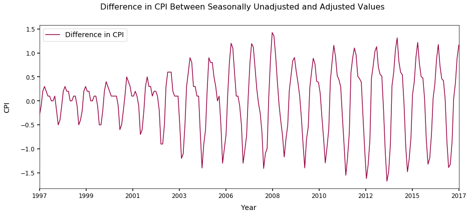

```python
xs = np.arange(0, len(us_monthly_sa0u))
ysu = us_monthly_sa0u.value
ys = us_monthly_sa0.value
vals = np.subtract(ysu, ys)

fig = plt.figure(figsize=[15, 6])
fig.suptitle('Difference in CPI Between Seasonally Unadjusted and Adjusted Values', fontsize=16, family='helvetica')

plt.axes().set_xlabel('Year', fontsize=14, labelpad=10)
plt.axes().set_ylabel('CPI', fontsize=14, labelpad=20)
plt.xlim(pdates[0], pdates[-1])
plt.axes().xaxis.set_major_locator(mpl.ticker.LinearLocator(numticks=10))
plt.axes().tick_params(length=5, width=1.5, labelsize=12)


plt.plot(pdates, vals, color='#980043')
plt.legend(['Difference in CPI'], prop={'size': 14})
plt.show()
```

**Figure 4: Difference in Adjusted and Unadjusted CPI from 1997 to 2017**

The periodic behavior of seasonal price change is more evident in this representation.

Lastly, I want to look at the change in CPI over time for different areas and different goods and services.

Areas of interest:

- Northeast Urban (0100)
- Midwest Urban (0200)
- South Urban (0300)
- West Urban (0400)

Items of interest:

- All items (SA0)
- Energy Commodities (Gasoline, Propane, Kerosene) (SACE)
- Food and Beverages (SAF)
- Transportation Services (SAS4)

These items were chosen by observing which `item_code` values are available for the given `area_code` values:

```python
current.query("area_code in ['0100', '0200', '0300', '0400']").item_code.value_counts().sort_index().head()
```

```
AA0       1308
SA0       1308
SA0E      1308
SA0L1     1308
SA0L1E    1308
Name: item_code, dtype: int64
```

```python
sa0 = current.query("item_code == 'SA0' & seasonality == 'U'& period in ['M01', 'M02', 'M03', 'M04', 'M05', 'M06', 'M07', 'M08', 'M09', 'M10', 'M11', 'M12']")
sace = current.query("item_code == 'SACE' & seasonality == 'U'& period in ['M01', 'M02', 'M03', 'M04', 'M05', 'M06', 'M07', 'M08', 'M09', 'M10', 'M11', 'M12']")
saf = current.query("item_code == 'SAF' & seasonality == 'U'& period in ['M01', 'M02', 'M03', 'M04', 'M05', 'M06', 'M07', 'M08', 'M09', 'M10', 'M11', 'M12']")
sas4 = current.query("item_code == 'SAS4' & seasonality == 'U'& period in ['M01', 'M02', 'M03', 'M04', 'M05', 'M06', 'M07', 'M08', 'M09', 'M10', 'M11', 'M12']")
```

For each `item_code`, the CPI values are available for 246 months:

```python
len(sa0.query("area_code == '0100'")), len(sa0.query("area_code == '0200'")), len(sa0.query("area_code == '0300'")), len(sa0.query("area_code == '0400'"))
```

```
(246, 246, 246, 246)
```

I then check if each start year/month and end year/month are the same for each `area_code`:

```python
area_codes = ['0100', '0200', '0300', '0400']
item_dfs = [sa0, sace, saf, sas4]
startys = []
endys = []
startms = []
endms = []
for i, df in enumerate(item_dfs):
    query_string = "area_code == " + area_codes[i]
    d = df.query(query_string)
    starty = int(df.year.min())
    endy = int(df.year.max())
    startm = int(df.period[df.index.min()][-2:])
    endm = int(df.period[df.index.max()][-2:])

    startys.append(starty)
    endys.append(endy)
    startms.append(startm)
    endms.append(endm)
```

```python
np.diff(np.asarray(startys)), np.diff(np.asarray(endys)), np.diff(np.asarray(startms)), np.diff(np.asarray(endms))
```

```
(array([0, 0, 0]), array([0, 0, 0]), array([0, 0, 0]), array([0, 0, 0]))
```

```python
def MakeDates(df):
    starty = int(df.year[df.index.min()])
    startm = int(df.period[df.index.min()][-2:])
    n = len(df)
    start = datetime.date(starty, startm, 1)

    pdates = []

    for i in range(n):
        date = start + relativedelta(months=+i)
        pdates.append(pd.to_datetime(date))
    return pdates
```

[figure not shown]

```python
area_codes = ['0100', '0200', '0300', '0400']
colors = ['#252525', '#d7301f', '#2171b5', '#238b45']
titles = ['Northeast Urban', 'Midwest Urban', 'South Urban', 'Midwest Urban']
dfs = [sa0, sace, saf, sas4]

fig, ax = plt.subplots(nrows=4, ncols=1, figsize=(12,15), sharex=True)

for i in range(len(area_codes)):
    for j, df in enumerate(dfs):
        query_string = 'area_code == ' + "'" + area_codes[i] + "'"
        d = df.query(query_string)
        vals = d.value
        pdates = MakeDates(d)
        ax[i].plot(pdates, vals, color=colors[j])
        ax[i].set_title(titles[i], fontsize=14)
        ax[i].grid(color='#d9d9d9', axis='x')
        ax[i].set_ylabel('CPI', fontsize=12)
        if i == 3:
            ax[i].legend(['All Items', 'Energy Commodities', 'Food and Beverages', 'Transportation Services'], prop={'size': 10})
            ax[i].set_xlabel('Year', fontsize=12)
plt.tight_layout()
plt.show()
```

Looking at the trends in the past 4 years (2013 - 2017) for all regions:

| **Item** | **Trend** |
| --- | --- |
| All items | Increasing |
| Energy Commodities | Decreasing |
| Food and Beverages | Leveling off |
| Transportation Services | Increasing |

## Next Steps

The (apparent) trend of each category will vary based on the time frame selected to assess the trend by observation. In order to arrive at a better prediction, I will look at two different models (linear regression vs. EWMA) in my next post on this dataset.